# project1

cherry

10/3/2019

## Chapter 3: Crime types and methods

In the first part, we will explore the frequency of the main types and methods of metro crime in DC. First, we need to find out what types of crimes often occur on the metro and try to classify these types of crimes. Then, as for the methods of committing crimes, we can divide them into crime with weapon and crime without weapon. So, before we start to explore the relationship of crime and other factors, we need to classify the types of crime.

```r
summary(crime$METHOD)
```

```
##    GUN  KNIFE OTHERS
##   1598    772  31413
```

```r
crime1<-subset(crime,METHOD=="GUN"|METHOD=="KNIFE",select=c(OFFENSE,METHOD))
```

#3.1 SMART Question Is there any correlation between types of crime and the use of weapons?

```r
summary(crime$OFFENSE)
```

```
##                      ARSON ASSAULT W/DANGEROUS WEAPON
##                          5                       1672
##                   BURGLARY                   HOMICIDE
##                       1419                        160
##        MOTOR VEHICLE THEFT                    ROBBERY
##                       2393                       2024
##                  SEX ABUSE               THEFT F/AUTO
##                        274                      11609
##                THEFT/OTHER
##                      14227
```

#3.2 Basic analysis (variables: OFFENSE/METHOD ways: bar chart/box plot/chi square?/……) It is better to classify the types into 3 or 4 types, and draw three plots(only offense only method and mixed)

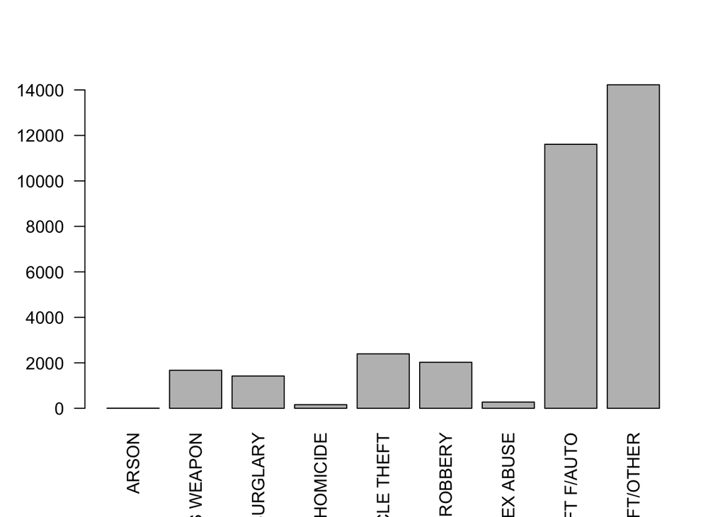

```r
library(ggplot2)
crime1$OFFENSE<- factor(crime1$OFFENSE)
crime1$METHOD<- factor(crime1$METHOD)
#lbs=c("Arson","Assault/Dangerous Weapon","Burglary","Homicide","MotorTheft","Robbery","Sexabuse","Theft/auto","Theft/other")
plot(crime$OFFENSE,las=2)
```

#3.2.1 Which types of crime occurs most in DC metro? Which occurs least?

[output not shown]

#3.2.3 What percentage of crimes are committed with weapons？

```
## [1] 0.07015363
```

## Chapter 5: Spot of crime

In this session, we seek to investigate the spatial distribution of the crimes in DC metro. We sought to analyze locations of crimes in DC area by category in order to derive insights into the crime rates of different area. This data set only covers basic geographic information about the location of the crime, and we can only speculate on why some areas have high crime rates in this project. It could be related to population density, economy, housing standards and some other possible factors.

#5.1 SMART Question Is the crime rate related to urban spatial distribution? Does the location will affect the types and methods of crime?